# Exercise Prediction with Random Forests

Daniel Maurath

June 16, 2015

### Executive Summary

The goal of this project for the Coursera Practical Machine Learning course was to use data from accelerometers on the belt, forearm, arm, and dumbell of 6 participants to predict the manner in which they did the exercise.

A random forests approach was used and resulted in a model with an prediction accuracy of: `0.969`

Expected out of sample error is: `.031`

#### Data

The data was provided by researchers at Pontifical Catholic University of Rio de Janeiro, Informatics Department and School of Computing and Communications, Lancaster University, UK.

See the CODEBOOK file for complete details on the dataset.

**Citation** *Ugulino, W.; Cardador, D.; Vega, K.; Velloso, E.; Milidiu, R.; Fuks, H. Wearable Computing: Accelerometers’ Data Classification of Body Postures and Movements. Proceedings of 21st Brazilian Symposium on Artificial Intelligence. Advances in Artificial Intelligence - SBIA 2012. In: Lecture Notes in Computer Science. , pp. 52-61. Curitiba, PR: Springer Berlin / Heidelberg, 2012. ISBN 978-3-642-34458-9. DOI: 10.1007/978-3-642-34459-6_6 http://groupware.les.inf.puc-rio.br/work.jsf?p1=10335*

### Required Libraries

```r
library(caret)
library(doParallel)
```

```r
library(ggplot2)
```

Allow R to use all four cores.

```r
cl <- makeCluster(detectCores())
registerDoParallel(cl)
```

### Data Cleaning

The dataset contained some columns with many missing values. These columns were summaries for time windows, so I discarded them. I also removed “bookkeeping” data in the first 7 columns. These columns were unique to this dataset and would not be useful when trying to make predictions out of sample.

```r
pml <- read.csv('pml-training.csv', na.strings=c("#DIV/0!", ""))

cs <- colSums(is.na(pml))
cs <- data.frame(col = names(cs), countNA = cs)
cs <- cs[order(-cs$countNA),]
row.names(cs) <- 1:nrow(cs)
head(cs,33)
```

```
##                        col countNA
## 1        kurtosis_yaw_belt   19622
## 2        skewness_yaw_belt   19622
## 3    kurtosis_yaw_dumbbell   19622
## 4    skewness_yaw_dumbbell   19622
## 5     kurtosis_yaw_forearm   19622
## 6     skewness_yaw_forearm   19622
## 7   kurtosis_picth_forearm   19301
## 8   skewness_pitch_forearm   19301
## 9    kurtosis_roll_forearm   19300
## 10         max_yaw_forearm   19300
## 11         min_yaw_forearm   19300
## 12   amplitude_yaw_forearm   19300
## 13   skewness_roll_forearm   19299
## 14      kurtosis_picth_arm   19296
```

[output cut: 19 more lines]

```r
kp <- as.character(cs[cs$countNA <= 0, "col"])
pml <- pml[kp]

pml <- pml[,-c(1:7)]
```

### Train-Test

To cross validate, I split the dataset into 60% train and 40% test. I leave the testing set alone for now, and build my features.

```r
set.seed(1987)
inTrain <- createDataPartition(y=pml$classe, p=0.60, list=FALSE)
training <- pml[inTrain,]
testing <- pml[-inTrain,]
```

### Feature Building

To reduce noise in the model, I remove predictors that have near zero variance using the nearZeroVar function in caret. I then remove any columns still in my testing set that are not in my training set.

```r
nzv <- nearZeroVar(training, saveMetrics=TRUE)
training <- training[,nzv$nzv==FALSE]
nzv <- nearZeroVar(testing,saveMetrics=TRUE)
testing <- testing[,nzv$nzv==FALSE]

testing <- testing[colnames(training)]
```

Another way to reduce noise, is to use Principal Components Analysis (PCA). This approach finds the best weighting and combination of correlated features. Here you can see many predictors are correlated, meaning this is a good case for PCA. I will use PCA when I train my model.

```r
M <- abs(cor(training[,-c(53)]))
diag(M) <- 0
which(M > 0.8, arr.ind=T)
```

```
##                  row col
## yaw_belt           3   1
## total_accel_belt   4   1
## accel_belt_y       9   1
## accel_belt_z      10   1
## accel_belt_x       8   2
## magnet_belt_x     11   2
## roll_belt          1   3
## roll_belt          1   4
## accel_belt_y       9   4
## accel_belt_z      10   4
## pitch_belt         2   8
## magnet_belt_x     11   8
## roll_belt          1   9
## total_accel_belt   4   9
## accel_belt_z      10   9
## roll_belt          1  10
## total_accel_belt   4  10
## accel_belt_y       9  10
## pitch_belt         2  11
## accel_belt_x       8  11
## magnet_belt_z     13  12
## magnet_belt_y     12  13
## gyros_arm_y       19  18
## gyros_arm_x       18  19
## magnet_arm_x      24  21
## accel_arm_x       21  24
## magnet_arm_z      26  25
## magnet_arm_y      25  26
## accel_dumbbell_x  34  28
## accel_dumbbell_z  36  29
## pitch_dumbbell    28  34
## yaw_dumbbell      29  36
```

### Random Forests Model

I chose Random Forests for my model because of its accuracy. As noted in Week 3’s Random Forest’s lecture, slide 10, “Random Forests are usually one of the top two performing algorithms.”

Admittedly, there are shortcomings to this model, but I addressed each. Random Forests is slow, so I used the “doParalell” package to take advantage of my computer’s 4 cores. Interpretability was not required for this assignment, only predictive accuracy. I used k-fold cross-validation during model training to address overfitting, as was suggested in lecture.

I trained the model on the training dataset using PCA to weigh and combine predictors, and 10 times cross validation. Then tested it using the testing dataset, and generated a confusion matrix to assess the model.

```r
modelfitRF <- train(training$classe~., method = "rf", preProcess=c("pca"), trControl = trainControl(method = "cv", number=10), data=training)
cm <- confusionMatrix(testing$classe, predict(modelfitRF, testing))
cm
```

```
## Confusion Matrix and Statistics
##
##           Reference
## Prediction    A    B    C    D    E
##          A 2212    5    6    8    1
##          B   41 1452   18    5    2
##          C    2   24 1316   23    3
##          D    4    2   68 1209    3
##          E    0    4   14    7 1417
##
## Overall Statistics
##
##                Accuracy : 0.969
##                  95% CI : (0.965, 0.973)
##     No Information Rate : 0.288
##     P-Value [Acc > NIR] : < 2e-16
##
##                   Kappa : 0.961
##  Mcnemar's Test P-Value : 2.3e-10
##
## Statistics by Class:
##
##                      Class: A Class: B Class: C Class: D Class: E
## Sensitivity             0.979    0.976    0.925    0.966    0.994
## Specificity             0.996    0.990    0.992    0.988    0.996
## Pos Pred Value          0.991    0.957    0.962    0.940    0.983
## Neg Pred Value          0.992    0.994    0.984    0.993    0.999
## Prevalence              0.288    0.190    0.181    0.160    0.182
## Detection Rate          0.282    0.185    0.168    0.154    0.181
## Detection Prevalence    0.284    0.193    0.174    0.164    0.184
## Balanced Accuracy       0.988    0.983    0.959    0.977    0.995
```

The model has a predictive accuracy of `0.969` and kappa of `0.961`

Out of sample error is 1 - 0.969 = `.031`

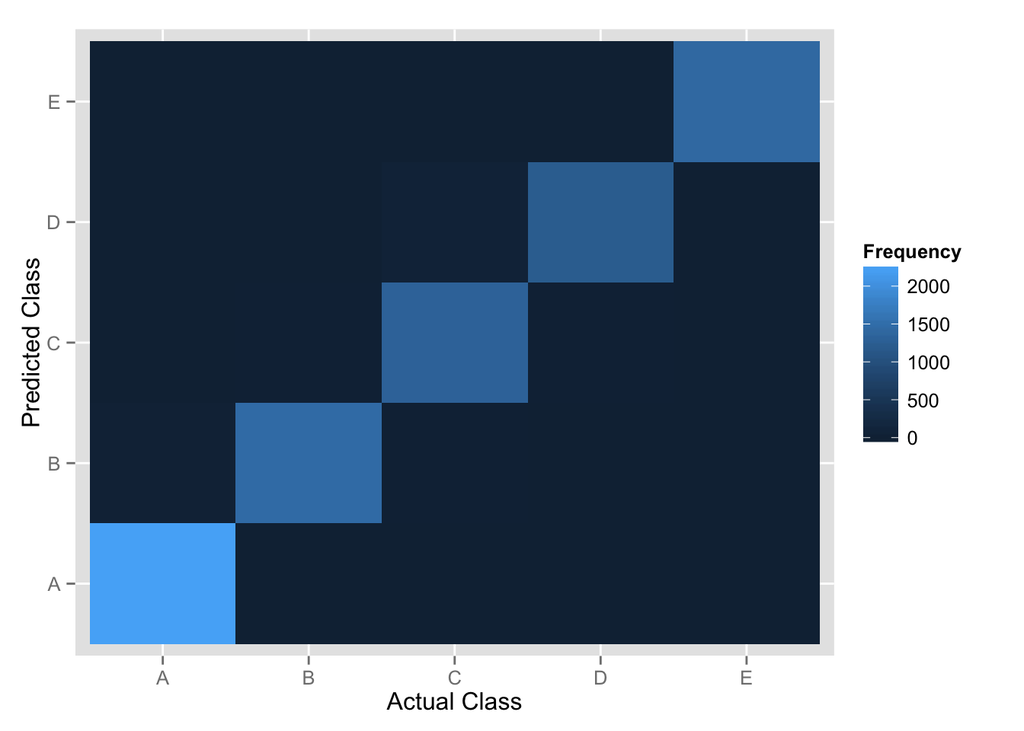

```r
cm_plot <- as.data.frame(cm[2])
names(cm_plot) <- c("Predicted", "Actual", "Freq")
plot <- ggplot(cm_plot)
plot + geom_tile(aes(x=Actual, y=Predicted, fill=Freq)) + scale_x_discrete(name="Actual Class") + scale_y_discrete(name="Predicted Class") + scale_fill_gradient() + labs(fill="Frequency")
```

That concludes this analysis.